# Introduction to MSI

NatCap TEEMs Skill Session

Matt Braaksma

University of Minnesota

March 24, 2025

## What is MSI?

**Minnesota Supercomputing Institute**

- Heterogeneous high-performance Linux cluster
- CPU Compute Nodes
  - 244 nodes have 512 GB of memory
  - 100 have 2TB of memory
- GPU Compute Nodes
  - 50 nodes have 4 A100 GPUs connected via NVLink and 512 GB of memory
  - 8 nodes have 8 A100s and 1 TB of memory
- More details at [MSI website](https://msi.umn.edu/about-msi-services/high-performance-computing/agate)

## What is HPC?

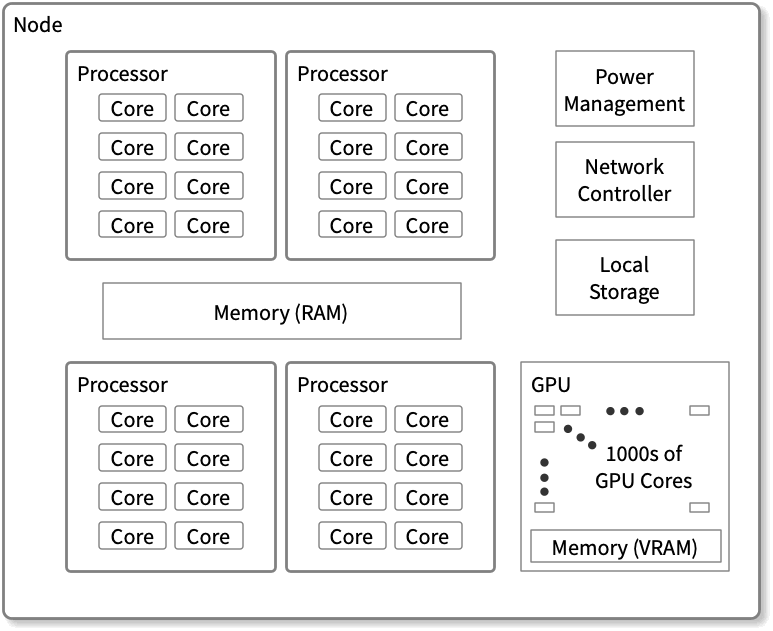

A conceptual depiction of a modern node with four eight-core processors that share a common memory pool. A node typically also handles local storage, network connectivity, and power. It is increasingly common for nodes to include special accelerator hardware like GPUs or TPUs. This node has a GPU.<sup>1</sup>

[^1]: https://cvw.cac.cornell.edu/parallel/hpc/nodes

## HPC vs. Regular Computing

| Feature | HPC | Regular Computing |
| --- | --- | --- |
| Processing Power | Many CPUs & GPUs across nodes | One or few CPUs with multiple cores |
| Parallelism | Massively parallel (distributed computing) | Limited parallelism (multi-threading within a CPU) |
| Scalability | High (thousands of nodes) | Low (single machine or few nodes) |
| Job Scheduling | **Slurm**, PBS, or LSF for batch scheduling | OS task scheduler (e.g., Windows Task Manager, cron) |

- More about [Slurm](https://slurm.schedmd.com/documentation.html)

## Background

### Command Line Basics

- Common Linux commands:
  - `ls` - List files
  - `cd` - Change directory
  - `pwd` - print working directory
  - `mkdir` - Create a directory
  - `mv` - move files
  - `rm` - Remove files
- [The Linux command line for beginners](https://ubuntu.com/tutorials/command-line-for-beginners#1-overview)

# Getting Set Up

## Getting Set Up

### Connect to MSI

1. Use Command Line
   - Terminal (Mac/Unix)
   - PuTTy (Windows)
     - [How do I configure PuTTy to connect to MSI Unix systems?](https://msi.umn.edu/our-resources/knowledge-base/interactive-connections-faqs/how-do-i-configure-putty-connect-msi-unix-systems)
2. Use VS Code
   - Much easier for editing code
   - Requires the Remote - SSH extension
     - Ctrl/Cmd+Shift+P
     - “Remote-SSH: Connect to Host…”

## Getting Set Up

### Connect to MSI

*NOTE:*

- Connecting to MSI requires
  1. UMN account and invite to group
  - Let me know if you did not receive an email
  2. Access to UMN network via
  - UMN WiFi
  - Using UMN’s VPN when off campus
  - [VPN guide from IT](https://it.umn.edu/services-technologies/virtual-private-network-vpn)

## Getting Set Up

### VS Code

Open the Command Palette (Ctrl/Cmd+Shift+P)

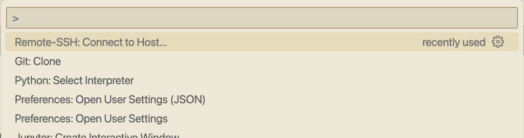

Add new host

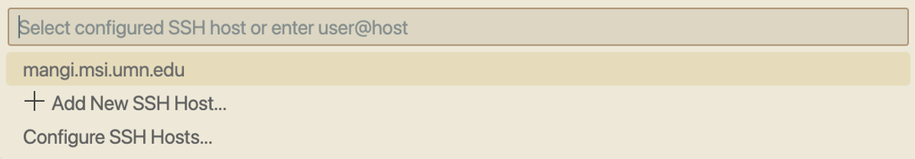

## Getting Set Up

### VS Code

Use `ssh` to connect to MSI

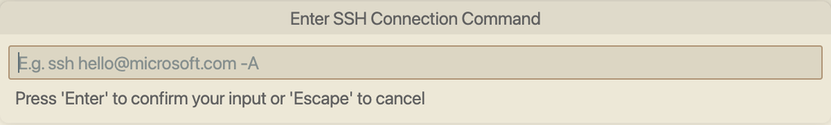

- `ssh username@mangi.msi.umn.edu`
- Enter your password and complete 2FA

## Getting Set Up

### VS Code

Now use VS Code to view your directory

[figure not shown]

## Getting Set Up

### VS Code

Now use VS Code to view your directory

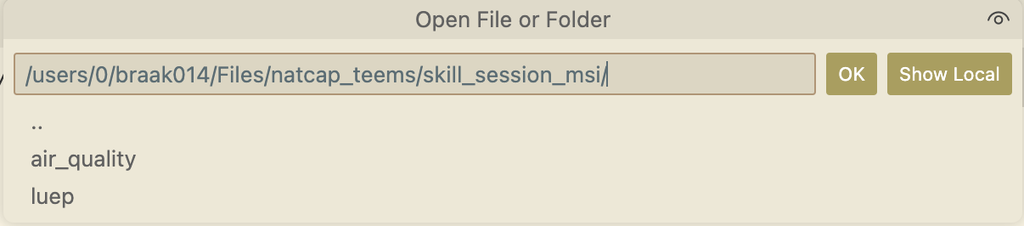

- For code, you can git clone directly into MSI

## Getting Set Up

### Transfer Data to MSI

Windows

- [Using WinSCP to transfer data](https://msi.umn.edu/our-resources/knowledge-base/file-transfer-faqs/how-do-i-use-winscp-transfer-data)

Mac

- [Using FileZilla to transfer data](https://msi.umn.edu/our-resources/knowledge-base/file-transfer-faqs/how-do-i-use-filezilla-transfer-data)

In the future…

- [Second Tier Storage via S3](https://msi.umn.edu/our-resources/knowledge-base/data-storage-faqs/what-are-some-user-friendly-ways-use-second-tier-storage-s3)
- Cyberduck (for Windows and Mac)
- [What are some user-friendly ways to use Second Tier Storage via S3?](https://msi.umn.edu/our-resources/knowledge-base/data-storage-faqs/what-are-some-user-friendly-ways-use-second-tier-storage-s3)

## Walkthrough

### Submitting a job

1. Set up conda environment
2. Git clone: `https://github.com/SumilThakr/luep`
3. Transfer data
4. Update python code
5. Create job script (.sh)
6. Submit sbatch

## Walkthrough

### Set up conda environment

Go to bash:

```bash
module load conda
conda create -n teems01 python=3 # create new venv
conda activate teems01 # or activate if already created
conda install -c conda-forge pyproj xarray rasterio pygeoprocessing scipy netCDF4
# install any necessary modules
```

## Walkthrough

### Git clone

Git clone to MSI (Ctrl/Cmd+Shift+P)

```bash
git clone https://github.com/SumilThakr/luep.git
```

## Walkthrough

### Transfer data

- Use FileZilla or WinSCP to transfer data
- From Google Drive:
  - Should be able to use [rclone](https://msi.umn.edu/our-resources/knowledge-base/data-storage-faqs/how-do-i-transfer-data-google-drive-panasas-tier-1-storage) to transfer data directly
  - ‘…/NatCapTEEMs/Files/base_data/submissions/air_quality’
  - Otherwise, copy to local machine first, then transfer
- To your MSI dir:
  - ‘~/Files/natcap_teems/skill_session_msi/’

## Walkthrough

### Update python code

- Open `run_deposition_calculation.py`
- Change inputdir
- Comment out some lines
  - Optional: add timer

## Walkthrough

### Update python

```python
# run_deposition_calculation.py
from dep_scripts import dep_1_lai_reclass
from dep_scripts import dep_2_lai_month_avg
from dep_scripts import dep_3_velocity
from dep_scripts import dep_4_multiply
import time

# inputdir = "/Users/sumilthakrar/UMN/Projects/landd2/pkg" # sumil local
# inputdir = "G:/Shared drives/NatCapTEEMs/Files/base_data/submissions/air_quality" # teems drive
inputdir = "~/Files/natcap_teems/skill_session_msi/air_quality"

def main():
    start_time = time.time()

    print("Reclassifying leaf area index")
    dep_1_lai_reclass.run(inputdir)
    print("Completed.\n")

    duration = time.time() - start_time
    print(f"Duration: {duration:.4f} seconds")

if __name__ == '__main__':
    main()
```

## Walkthrough

### Job Submission and Scheduling with Slurm

- **MSI uses Slurm** to manage computational resources efficiently.
- Jobs are submitted to a **queue (partition)** and wait for available resources.
- Users must create **Slurm job scripts** to request resources and execute calculations.

### Writing and Submitting Job Scripts

1. **Writing Job Scripts** – Define resource requests and execution commands.
2. **Submitting Job Scripts** – Use `sbatch` to submit jobs to Slurm.
3. **Slurm Directives** – Specify job parameters with `#SBATCH` directives.

## Walkthrough

### Create job script (.sh)

```python
#!/bin/bash -l
# Specifies the shell to use for the script (bash in this case), and the -l option makes it a login shell

# Slurm directives to request resources
#SBATCH --time=0:10:00  # Set the maximum runtime for the job to 10 minutes
#SBATCH --ntasks=1      # Request 1 task (process) for this job
#SBATCH --mem=10g       # Request 10GB of RAM
#SBATCH --tmp=10g       # Request 10GB of temporary (scratch) disk space
#SBATCH --mail-type=ALL  # Receive emails on all events (start, end, fail)
#SBATCH --mail-user=braak014@umn.edu  # Set email address to receive notifications

# Change to the specified working directory
cd ~/Files/natcap_teems/skill_session_msi/luep

# Load the necessary software modules
module load python3  # Load the Python 3 module
module load conda    # Load the Conda module

# Manually source the .bashrc file to initialize Conda
source ~/.bashrc  # Ensures that Conda is properly initialized before use

# Activate the Conda environment where dependencies are set up
conda activate teems01  # Activate the Conda environment "teems01"

# Run the Python script
python3 run_deposition_calculation.py  # Executes the specified Python script using Python 3
```

## Walkthrough

### Submit sbatch

```bash
sbatch submit_run_deposition_calc.sh
squeue -u username # to check status of jobs
# scancel jobIDnumber # to cancel a job
```

- Note: you need to be in the same dir
  - Ex: (base) braak014@ahl01 [~/Files/natcap_teems/skill_session_msi/luep] % sbatch submit_run_deposition_calc.sh

## Walkthrough

### Output

File `slurm-33362574.out` saved to same dir

```bash
Reclassifying leaf area index
Completed.

Duration: 25.4040 seconds
```

Compared to local machine:

```bash
Reclassifying leaf area index
Completed.

Duration: 45.3438 seconds
```

## Next Steps & Other options

- Set up complete devstack on MSI
  - Transfer all base data
  - Use Second Tier Storage
- Gain experience with `srun` and [Interactive Job Support](https://msi.umn.edu/about-msi-services/interactive-hpc/interactive-computing-srun)
  - Should be able to use debugging feature
- Set up ssh config file to avoid repeated logins
- Other Options
  - [Open OnDemand](https://msi.umn.edu/about-msi-services/interactive-hpc/open-ondemand)
  - Jupyter
  - Rstudio servers